# tejas_transformer_model

```python
# Code to test if GPUs are available
import os
os.environ['TF_CPP_MIN_LOG_LEVEL'] = '3'
import tensorflow as tf

# Check TensorFlow version
print("TensorFlow version:", tf.__version__)

# List available physical devices
gpus = tf.config.list_physical_devices('GPU')
print("Num GPUs Available:", len(gpus))
print("GPU Details:", gpus)
```

```
TensorFlow version: 2.14.0
Num GPUs Available: 2
GPU Details: [PhysicalDevice(name='/physical_device:GPU:0', device_type='GPU'), PhysicalDevice(name='/physical_device:GPU:1', device_type='GPU')]
```

```python
import os
import random
import numpy as np
import cv2
from glob import glob
import tensorflow as tf
import matplotlib.pyplot as plt
import seaborn as sns
from tqdm import tqdm

from tensorflow.keras.models import Model, load_model
from tensorflow.keras import layers
from tensorflow.keras.layers import Dense, Dropout
from tensorflow.keras.optimizers import Adam
from tensorflow.keras.callbacks import EarlyStopping, ModelCheckpoint
from tensorflow.keras.losses import BinaryCrossentropy
from tensorflow.keras.layers import RandomFlip, RandomRotation
from tensorflow.keras.preprocessing import image_dataset_from_directory
from tensorflow.keras import Sequential

from vit_keras import vit, utils

from sklearn.utils import class_weight
from sklearn.metrics import (
    classification_report, confusion_matrix, accuracy_score,
    roc_curve, auc, precision_recall_curve, f1_score, roc_auc_score
)
```

!pip install vit-keras

!pip install tensorflow-addons

# **Vision Transformer (ViT) – Novel Deep Learning Approach**

## Why it's different: ViT uses transformer architecture (popular in NLP) directly on images. It captures global context far better than CNNs.

## Advantages:

### Great generalization with less data.

### Captures long-range dependencies in images (good for scenes like empty vs. occupied).

### Totally different from ResNet/VGG-based pipelines.

# **Step-by-step ViT Setup (Using Pretrained ViT-B16)**

## 1. Imports & Strategy Setup (for GPU parallelism)

```python
# === Paths ===
train_dir = os.path.abspath(os.path.join("..", "..", "DATA", "archive", "train"))
valid_dir = os.path.abspath(os.path.join("..", "..", "DATA", "archive", "valid"))

strategy = tf.distribute.MirroredStrategy()
print(f"Number of devices: {strategy.num_replicas_in_sync}")

# === Constants ===
IMG_SIZE = 224
BATCH_SIZE = 32
AUTOTUNE = tf.data.AUTOTUNE
```

```
INFO:tensorflow:Using MirroredStrategy with devices ('/job:localhost/replica:0/task:0/device:GPU:0', '/job:localhost/replica:0/task:0/device:GPU:1')
Number of devices: 2
```

```python
# === Load and Preprocess Data ===
train_ds = image_dataset_from_directory(
    train_dir,
    image_size=(IMG_SIZE, IMG_SIZE),
    batch_size=BATCH_SIZE,
    label_mode='int',
    shuffle=True,
    seed=42
)

valid_ds = image_dataset_from_directory(
    valid_dir,
    image_size=(IMG_SIZE, IMG_SIZE),
    batch_size=BATCH_SIZE,
    label_mode='int',
    shuffle=False
)

# === Define Augmentation Pipeline ===
data_augmentation = Sequential([
    RandomFlip("horizontal"),
    RandomRotation(0.1),
])

# === Apply Augmentation and Rescaling ONLY to Training Set ===
train_ds = train_ds.map(lambda x, y: (data_augmentation(x, training=True), y))
train_ds = train_ds.map(lambda x, y: (tf.cast(x, tf.float32) / 255.0, y))

# === Rescale Validation Set (no augmentation) ===
valid_ds = valid_ds.map(lambda x, y: (tf.cast(x, tf.float32) / 255.0, y))

# === Prefetch for Performance ===
train_ds = train_ds.prefetch(buffer_size=AUTOTUNE)
valid_ds = valid_ds.prefetch(buffer_size=AUTOTUNE)
```

```
Found 8503 files belonging to 2 classes.
Found 2424 files belonging to 2 classes.
```

# **2. Inside Strategy Scope: Build ViT Model**

# **For the cell below We have following choices**

## Since our problem is binary classification:

## We can use either:

### Option A (softmax + sparse_categorical_crossentropy)

### Option B (sigmoid + binary_crossentropy)

# **Comparison between two is given below**

### Comparison: `sigmoid` + `binary_crossentropy` vs `softmax` + `sparse_categorical_crossentropy`

| Aspect | Sigmoid + Binary Crossentropy | Softmax + Sparse Categorical Crossentropy |
| --- | --- | --- |
| Output Layer | `Dense(1, activation='sigmoid')` | `Dense(2, activation='softmax')` |
| Target Labels | `0` or `1` | `0` or `1` (class indices) |
| Model Output | One probability (e.g. P(occupied)) | Two probabilities (e.g. P(empty), P(occupied)) |
| Prediction Format | `output > 0.5` (or threshold tuned) | `np.argmax(output)` or threshold on one of the softmax outputs |
| Threshold Tuning | Possible, but only on 1 class | Easier, can tune on either class |
| Preferred When | Binary classification only | Binary but modeled like multiclass (for flexibility) |
| Example Loss Function | `'binary_crossentropy'` | `'sparse_categorical_crossentropy'` |
| Compatibility with Softmax | Not applicable | Built-in |

[output not shown]

# **2. Inside Strategy Scope: Build ViT Model**

```python
with strategy.scope():
    # Load base ViT model
    vit_model = vit.vit_b16(
        image_size=IMG_SIZE,
        activation=None,
        pretrained=True,
        include_top=False,
        pretrained_top=False
    )

    # Custom top layers
    x = vit_model.output
    x = Dense(128, activation='relu')(x)
    x = Dropout(0.5)(x)                        # Increased dropout
    # Optional second dropout layer
    x = Dense(64, activation='relu')(x)
    x = Dropout(0.3)(x)                        # Additional regularization
    output = Dense(1, activation='sigmoid')(x)

    model = Model(inputs=vit_model.input, outputs=output)

    vit_model.trainable = True  # Unfreeze backbone

    # Compile
    model.compile(
        optimizer=Adam(learning_rate=1e-5),
        loss=BinaryCrossentropy(),
        metrics=['accuracy']
    )

model.summary()
```

```
Model: "model_1"
_________________________________________________________________
 Layer (type)                Output Shape              Param #
=================================================================
 input_2 (InputLayer)        [(None, 224, 224, 3)]     0

 embedding (Conv2D)          (None, 14, 14, 768)       590592

 reshape_1 (Reshape)         (None, 196, 768)          0

 class_token (ClassToken)    (None, 197, 768)          768

 Transformer/posembed_input  (None, 197, 768)          151296
  (AddPositionEmbs)

 Transformer/encoderblock_0  ((None, 197, 768),        7087872
  (TransformerBlock)          (None, 12, None, None)
                             )

 Transformer/encoderblock_1  ((None, 197, 768),        7087872
  (TransformerBlock)          (None, 12, None, None)
                             )

 Transformer/encoderblock_2  ((None, 197, 768),        7087872
  (TransformerBlock)          (None, 12, None, None)
                             )

 Transformer/encoderblock_3  ((None, 197, 768),        7087872
  (TransformerBlock)          (None, 12, None, None)
                             )

 Transformer/encoderblock_4  ((None, 197, 768),        7087872
  (TransformerBlock)          (None, 12, None, None)
                             )

 Transformer/encoderblock_5  ((None, 197, 768),        7087872
  (TransformerBlock)          (None, 12, None, None)
                             )

 Transformer/encoderblock_6  ((None, 197, 768),        7087872
```

[output cut: 28 more lines]

```
 dense_3 (Dense)             (None, 128)               98432

 dropout_2 (Dropout)         (None, 128)               0

 dense_4 (Dense)             (None, 64)                8256

 dropout_3 (Dropout)         (None, 64)                0

 dense_5 (Dense)             (None, 1)                 65

=================================================================
Total params: 85905409 (327.70 MB)
Trainable params: 85905409 (327.70 MB)
Non-trainable params: 0 (0.00 Byte)
_________________________________________________________________
```

# **4. Train the Model with Callbacks using train_ds**

```python
# === Callbacks ===
callbacks = [
    EarlyStopping(monitor='val_loss', patience=5, restore_best_weights=True, verbose=1),
    ModelCheckpoint("vit_model.h5", save_best_only=True)  # Use legacy format for compatibility
]

# === Train ===
history = model.fit(
    train_ds,
    validation_data=valid_ds,
    epochs=20,
    callbacks=callbacks
)
```

[output not shown]

```
Epoch 19: early stopping
```

# **What the Output Showed (Fine-Tuned ViT with Augmentation + Dropout)**

[output not shown]

# Saving legacy format model vit_model.h5 to modern tensorflow format

# **Summary**

### The modifications (dropout + augmentation) clearly improved generalization and stability.

```python
# Load the model saved in HDF5 format
model = tf.keras.models.load_model("vit_model.h5")

# Save the model in the TensorFlow SavedModel format
model.save("vit_model_savedmodel", save_format='tf')

# Verify by loading the SavedModel
loaded_model = tf.keras.models.load_model("vit_model_savedmodel")

# Optionally, check the model structure
loaded_model.summary()
```

```
INFO:tensorflow:Assets written to: vit_model_savedmodel/assets
```

```
INFO:tensorflow:Assets written to: vit_model_savedmodel/assets
```

```
Model: "model_1"
_________________________________________________________________
 Layer (type)                Output Shape              Param #
=================================================================
 input_2 (InputLayer)        [(None, 224, 224, 3)]     0

 embedding (Conv2D)          (None, 14, 14, 768)       590592

 reshape_1 (Reshape)         (None, 196, 768)          0

 class_token (ClassToken)    (None, 197, 768)          768

 Transformer/posembed_input  (None, 197, 768)          151296
  (AddPositionEmbs)

 Transformer/encoderblock_0  ((None, 197, 768),        7087872
  (TransformerBlock)          (None, 12, None, None)
                             )

 Transformer/encoderblock_1  ((None, 197, 768),        7087872
  (TransformerBlock)          (None, 12, None, None)
                             )

 Transformer/encoderblock_2  ((None, 197, 768),        7087872
  (TransformerBlock)          (None, 12, None, None)
                             )

 Transformer/encoderblock_3  ((None, 197, 768),        7087872
  (TransformerBlock)          (None, 12, None, None)
                             )

 Transformer/encoderblock_4  ((None, 197, 768),        7087872
  (TransformerBlock)          (None, 12, None, None)
                             )

 Transformer/encoderblock_5  ((None, 197, 768),        7087872
  (TransformerBlock)          (None, 12, None, None)
                             )

 Transformer/encoderblock_6  ((None, 197, 768),        7087872
```

[output cut: 28 more lines]

```
 dense_3 (Dense)             (None, 128)               98432

 dropout_2 (Dropout)         (None, 128)               0

 dense_4 (Dense)             (None, 64)                8256

 dropout_3 (Dropout)         (None, 64)                0

 dense_5 (Dense)             (None, 1)                 65

=================================================================
Total params: 85905409 (327.70 MB)
Trainable params: 85905409 (327.70 MB)
Non-trainable params: 0 (0.00 Byte)
_________________________________________________________________
```

# **Function: plot_P-R curve and find threshold for best_F1 . Also plot AUC ROC curve**

```python
def plot_pr_and_roc(model, dataset, set_name="Validation"):
    """
    Plots both Precision-Recall and ROC curves, computes F1 scores across thresholds,
    and returns the best threshold based on F1 score.
    """

    # === True labels and predicted scores ===
    y_true = np.concatenate([y.numpy() for _, y in dataset], axis=0)
    y_scores = model.predict(dataset).squeeze()

    # === Precision-Recall Curve ===
    precision, recall, pr_thresholds = precision_recall_curve(y_true, y_scores)
    f1_scores = 2 * (precision * recall) / (precision + recall + 1e-8)
    best_idx = np.argmax(f1_scores)
    best_threshold = pr_thresholds[best_idx]
    best_f1 = f1_scores[best_idx]

    # === ROC Curve and AUC ===
    fpr, tpr, _ = roc_curve(y_true, y_scores)
    auc_score = roc_auc_score(y_true, y_scores)

    # === Plot both ===
    plt.figure(figsize=(14, 6))

    # Precision–Recall Curve
    plt.subplot(1, 2, 1)
    plt.plot(recall, precision, label=f'{set_name} P-R Curve')
    plt.scatter(recall[best_idx], precision[best_idx], color='red',
                label=f'Best F1={best_f1:.2f} @ Threshold={best_threshold:.2f}')
    plt.xlabel("Recall")
    plt.ylabel("Precision")
    plt.title(f"Precision-Recall Curve ({set_name})")
    plt.grid(True)
    plt.legend()

    # ROC Curve
    plt.subplot(1, 2, 2)
    plt.plot(fpr, tpr, label=f"AUC = {auc_score:.4f}", color='orange')
    plt.plot([0, 1], [0, 1], linestyle='--', color='gray')
    plt.xlabel("False Positive Rate")
    plt.ylabel("True Positive Rate")
    plt.title(f"ROC Curve ({set_name})")
    plt.grid(True)
    plt.legend()

    plt.tight_layout()
    plt.show()

    print(f"\nBest Threshold by F1 Score: {best_threshold:.2f} (F1 = {best_f1:.2f})")
    print(f"AUC-ROC Score: {auc_score:.4f}")

    return best_threshold, best_f1
```

# **Create train_ds, test_ds and valid_ds using resuable function below**

```python
def load_dataset_for_prediction(directory, img_size=(224, 224), batch_size=32):
    """
    Load image dataset for prediction (no shuffling, normalized, with labels).

    Args:
        directory (str): Path to the dataset directory.
        img_size (tuple): Target image size (height, width).
        batch_size (int): Batch size.

    Returns:
        tf.data.Dataset: Prepared dataset (images normalized, labels intact).
    """
    dataset = tf.keras.utils.image_dataset_from_directory(
        directory,
        labels='inferred',
        label_mode='int',
        image_size=img_size,
        batch_size=batch_size,
        shuffle=False
    )

    # Normalize images to [0, 1]
    dataset = dataset.map(lambda x, y: (x / 255.0, y))
    return dataset
```

```python
VALID_DIR = os.path.abspath(os.path.join("..", "..", "DATA", "archive", "valid"))
TEST_DIR = os.path.abspath(os.path.join("..", "..", "DATA", "archive", "test"))
valid_ds = load_dataset_for_prediction(VALID_DIR)
test_ds  = load_dataset_for_prediction(TEST_DIR)
```

```
Found 2424 files belonging to 2 classes.
Found 1216 files belonging to 2 classes.
```

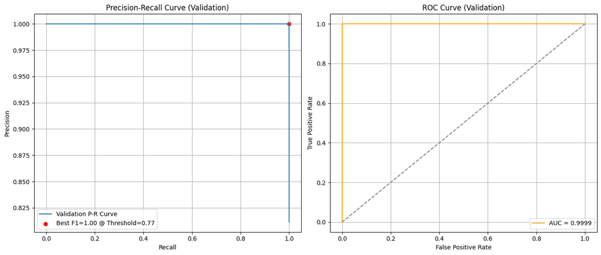

```
Best Threshold by F1 Score: 0.77 (F1 = 1.00)
AUC-ROC Score: 0.9999
```

```python
# For validation set
best_threshold, best_f1 = plot_pr_and_roc(model, valid_ds, set_name="Validation")
```

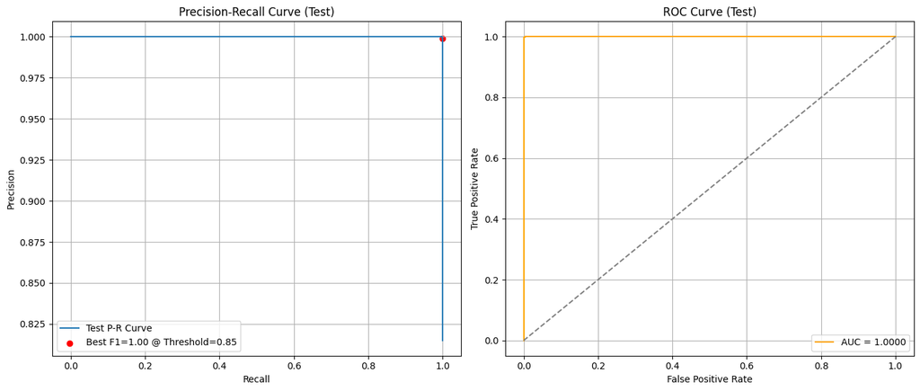

```
Best Threshold by F1 Score: 0.85 (F1 = 1.00)
AUC-ROC Score: 1.0000
```

```python
# For test set
best_threshold, best_f1 = plot_pr_and_roc(model, test_ds, set_name="Test")
```